# Linguistic Data: Quantitative Analysis and Visualisation

Lab 3. Student`s t-test. Binomial test. R: Simulating data, boxplots, density plots

## Student’s t-test

### Aspiration and vowel duration in Icelandic

This set is based on (Coretta 2017, [link](https://goo.gl/NrfgJm)). This dissertation dealt with the relation between vowel duration and aspiration in consonants. Author carried out a data collection with 5 natives speakers of Icelandic. Then he extracted the duration of vowels followed by aspirated versus non-aspirated consonants. Check out whether vowels before aspirated consonants (like in Icelandic takka ‘key’ [tʰaʰka]) are signiﬁcantly shorter than vowels followed by non-aspirated consonants (like in kagga ‘barrel’ [kʰakka]).  
[Link](https://raw.githubusercontent.com/LingData2019/LingData2020/master/data/icelandic.csv) to the dataset.

```r
Sys.setlocale("LC_ALL", 'en_US.UTF-8')
```

```
## [1] "en_US.UTF-8/en_US.UTF-8/en_US.UTF-8/C/en_US.UTF-8/C"
```

```r
library(readr)
library(tidyverse)
df <- read_csv("https://raw.githubusercontent.com/LingData2019/LingData2020/master/data/icelandic.csv")
```

### Descriptive statistics

A general boxplot:

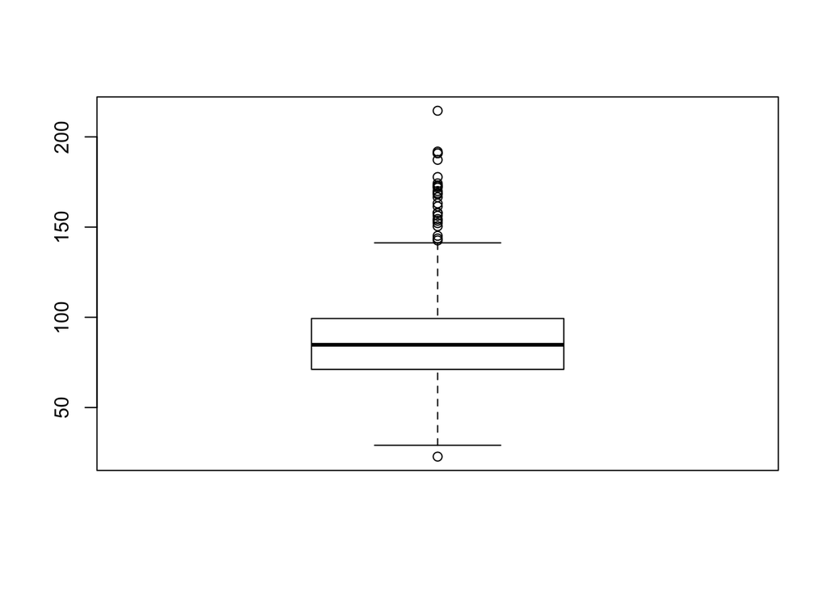

```r
boxplot(df$vowel.dur)
```

Get the number of outliers:

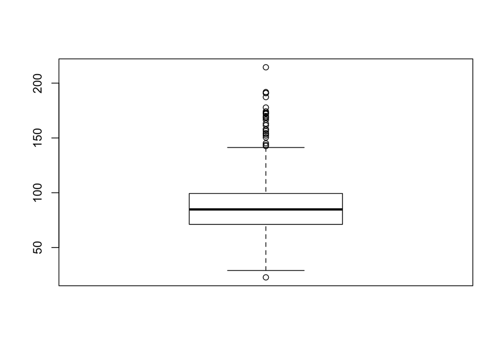

```
## [1] 27
```

```r
length(boxplot(df$vowel.dur)$out)
```

Look at number of observations by groups (aspirated and non-aspirated cases):

```r
table(df$aspiration)
```

```
##
##  no yes
## 401 405
```

Choose two subsamples, one for words where vowels are followed by aspirated consonants and another for non-aspirated consonants.

```r
asp <- df[df$aspiration == 'yes',]
nasp <- df[df$aspiration == 'no',]
```

Summary for aspirated and non-aspirated cases:

```r
summary(asp$vowel.dur)
```

```
##    Min. 1st Qu.  Median    Mean 3rd Qu.    Max.
##   22.78   64.96   77.60   78.76   91.46  166.60
```

```r
summary(nasp$vowel.dur)
```

```
##    Min. 1st Qu.  Median    Mean 3rd Qu.    Max.
##   37.98   77.56   91.91   94.69  103.90  214.50
```

Boxplot by groups:

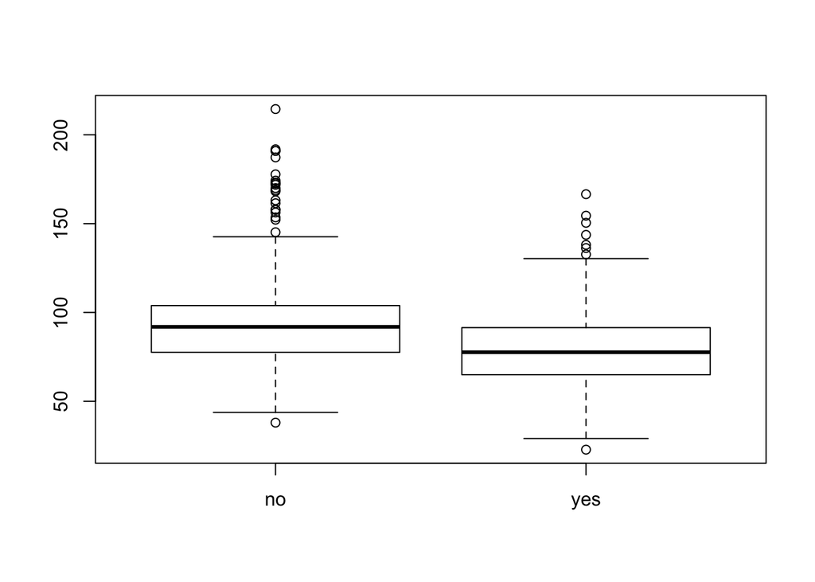

```r
boxplot(df$vowel.dur ~ df$aspiration)
```

More interesting - let us create a boxplot by all groups (see the field `cons1`):

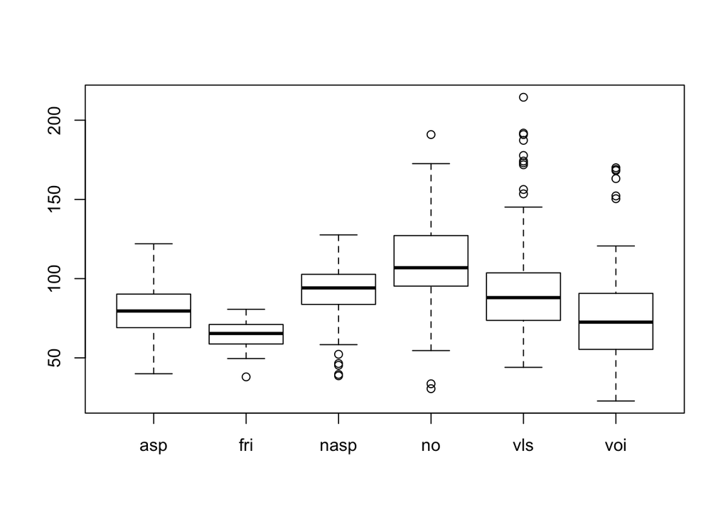

```r
boxplot(df$vowel.dur ~ df$cons1)
```

You can compare distribution of `vowel.dur` in asp(irated), fri(cative), nasp(non-aspirated), voi(ced), etc.

We can limit our data to just one type of vowels, say, middle vowels. Therefore, we will work with the same type of a consonant:

```r
asp <- df[df$aspiration == 'yes' & df$height == 'mid', ]
nasp <- df[df$aspiration == 'no' & df$height == 'mid', ]
```

Again, here is a summary for a corrected case:

```r
summary(asp$vowel.dur)
```

```
##    Min. 1st Qu.  Median    Mean 3rd Qu.    Max.
##   38.67   71.41   81.92   82.65   95.19  150.50
```

```r
summary(nasp$vowel.dur)
```

```
##    Min. 1st Qu.  Median    Mean 3rd Qu.    Max.
##   37.98   80.90   97.97   98.73  110.50  190.90
```

```r
nrow(asp)
```

```
## [1] 156
```

```r
nrow(nasp)
```

```
## [1] 174
```

### T-test

Let us formulate the null hypothesis, the alternative hypotesis, and apply t-test to our dataset.

```r
t.test(asp$vowel.dur, nasp$vowel.dur)
```

```
##
##  Welch Two Sample t-test
##
## data:  asp$vowel.dur and nasp$vowel.dur
## t = -6.4869, df = 317.72, p-value = 3.356e-10
## alternative hypothesis: true difference in means is not equal to 0
## 95 percent confidence interval:
##  -20.94772 -11.19801
## sample estimates:
## mean of x mean of y
##  82.65371  98.72657
```

By default, R calculates t.test with regard to the bi-directional alternative hypothesis, such as $\mu_1 \neq \mu_2$.

### Unidirectional t-test

H1: $\mu_{asp} \lt \mu_{nasp}$

```r
t.test(asp$vowel.dur, nasp$vowel.dur, alternative = "less")
```

```
##
##  Welch Two Sample t-test
##
## data:  asp$vowel.dur and nasp$vowel.dur
## t = -6.4869, df = 317.72, p-value = 1.678e-10
## alternative hypothesis: true difference in means is less than 0
## 95 percent confidence interval:
##       -Inf -11.98542
## sample estimates:
## mean of x mean of y
##  82.65371  98.72657
```

### Density plots

```r
require(tidyverse)
require(dplyr)
```

Let’s get a descriptive summary of our data in a dplyr style.

```r
df %>%
  group_by(aspiration) %>%
  summarise(mean = mean(vowel.dur),
            st.dev = sd(vowel.dur))
```

| aspiration | mean | st.dev |
| --- | --- | --- |
| no | 94.69124 | 25.85561 |
| yes | 78.75772 | 21.24177 |

Density plots can be thought of as plots of smoothed histograms.

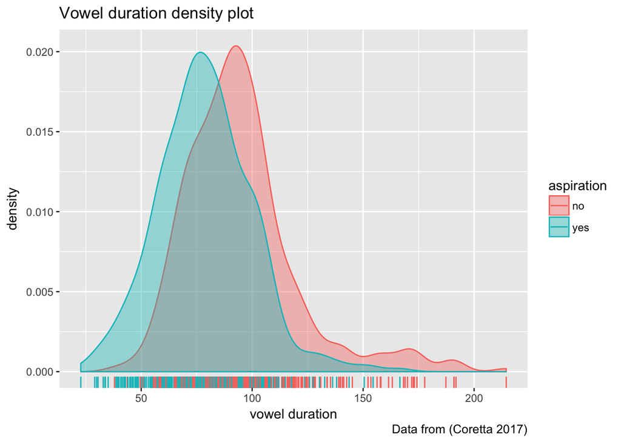

```r
library(ggplot2)
df %>%
  ggplot(aes(vowel.dur, fill = aspiration, color = aspiration))+
  geom_density(alpha = 0.4)+
  geom_rug()+
  labs(title = "Vowel duration density plot",
       caption = "Data from (Coretta 2017)",
       x = "vowel duration")
```

Density plot by speaker:

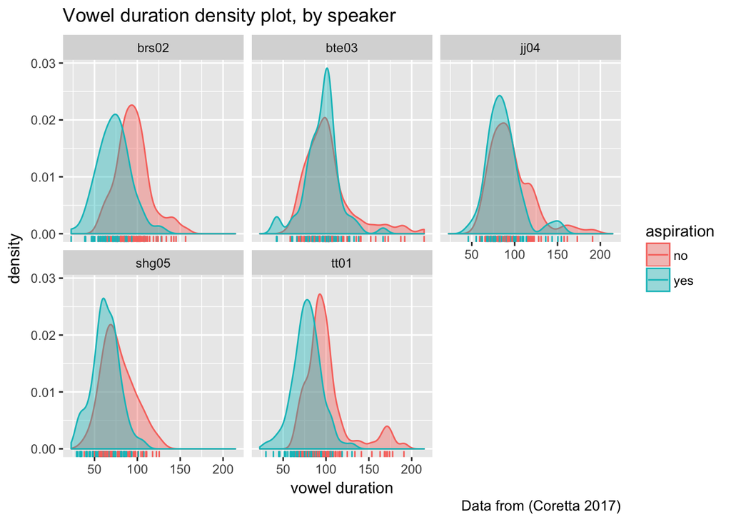

```r
df %>%
  ggplot(aes(vowel.dur, fill = aspiration, color = aspiration))+
  geom_density(alpha = 0.4)+
  geom_rug()+
  facet_wrap(~speaker)+
  labs(title = "Vowel duration density plot, by speaker",
       caption = "Data from (Coretta 2017)",
       x = "vowel duration")
```

and descriptive statistics:

```r
df %>%
  group_by(aspiration, speaker) %>%
  summarise(mean = mean(vowel.dur),
            st.dev = sd(vowel.dur))
```

| aspiration | speaker | mean | st.dev |
| --- | --- | --- | --- |
| no | brs02 | 95.27593 | 19.81246 |
| no | bte03 | 102.75791 | 29.38451 |
| no | jj04 | 95.72652 | 25.13620 |
| no | shg05 | 77.65635 | 18.86992 |
| no | tt01 | 100.59767 | 26.77305 |
| yes | brs02 | 72.87988 | 18.85812 |
| yes | bte03 | 95.40109 | 20.03149 |
| yes | jj04 | 86.80463 | 20.06335 |
| yes | shg05 | 63.27287 | 15.72727 |
| yes | tt01 | 78.25853 | 16.74632 |

## Simulating data

Create a matrix 2 * 3 consisting of 0:

```r
matrix(0, nrow=2, ncol=3)
```

```
##      [,1] [,2] [,3]
## [1,]    0    0    0
## [2,]    0    0    0
```

Arrange a vector of 12 values into matrix 3 * 4 arrange by rows:

```r
v <- 1:12
m <- matrix(v, n=3, ncol=4, byrow = TRUE)
m
```

```
##      [,1] [,2] [,3] [,4]
## [1,]    1    2    3    4
## [2,]    5    6    7    8
## [3,]    9   10   11   12
```

Sum of every row in a matrix:

```r
rowSums(m)
```

```
## [1] 10 26 42
```

Create a sample of 0 and 1 of size 10.

```r
sample(c(0, 1), 10, replace = TRUE)
```

```
##  [1] 0 1 1 1 1 0 0 0 0 1
```

### Sample size and variance

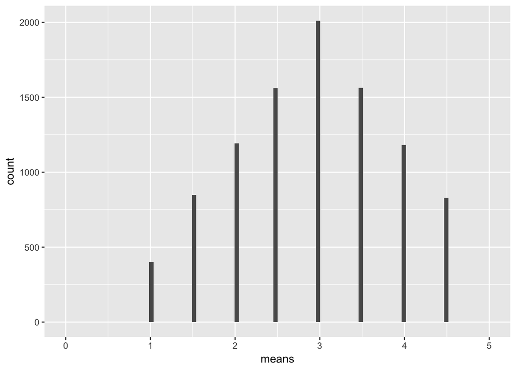

```r
population <- c(1, 2, 3, 4, 5)
sample_size <- 2
means <- rep(NA, 10000)
for (i in 1:10000) {
  samp <- sample(population, size=sample_size, replace=TRUE)
  means[i] <- mean(samp)
}
library(ggplot2)
ggplot() +
  geom_histogram(aes(means), bins = 100) +
  xlim(c(0, 5))
```

Now you can change the sample size to see how the distribution of means changes.

See also code for [Simulating variance estimates](https://rstudio-pubs-static.s3.amazonaws.com/237011_27e85fe7e17e4c73a260cb27e60fb012.html)

## Binomial test

Experiment: toss a coin 10 times and repeat this sequence 10000 times:

```r
tosses <- 10
samples <- 10000
dat <- matrix(sample(c(0, 1), tosses * samples, replace=TRUE), ncol=tosses, byrow=TRUE)
```

Calculate `phats` - proportions of heads in each experiment:

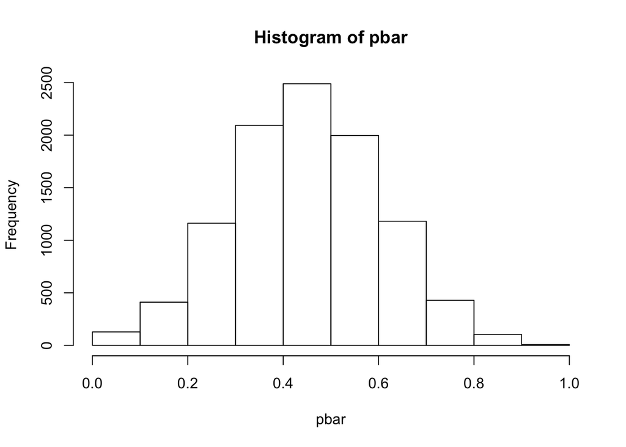

```r
pbar <- rowSums(dat) / tosses
hist(pbar, breaks=tosses, xlim=c(0, 1))
```

Test $H_0: p = 0.5$:

```r
binom.test(3, 10, p=0.5) # 3 out of 10 - a fair coin?
```

```
##
##  Exact binomial test
##
## data:  3 and 10
## number of successes = 3, number of trials = 10, p-value = 0.3438
## alternative hypothesis: true probability of success is not equal to 0.5
## 95 percent confidence interval:
##  0.06673951 0.65245285
## sample estimates:
## probability of success
##                    0.3
```

```r
binom.test(2, 10)  # 2 out of 10 - a fair coin?
```

```
##
##  Exact binomial test
##
## data:  2 and 10
## number of successes = 2, number of trials = 10, p-value = 0.1094
## alternative hypothesis: true probability of success is not equal to 0.5
## 95 percent confidence interval:
##  0.02521073 0.55609546
## sample estimates:
## probability of success
##                    0.2
```

```r
binom.test(1, 10)  # 1 out of 10 - a fair coin?
```

```
##
##  Exact binomial test
##
## data:  1 and 10
## number of successes = 1, number of trials = 10, p-value = 0.02148
## alternative hypothesis: true probability of success is not equal to 0.5
## 95 percent confidence interval:
##  0.002528579 0.445016117
## sample estimates:
## probability of success
##                    0.1
```

Load some dataset and check some null hypothesis with binomial test.

```r
df <- read.csv("https://raw.githubusercontent.com/LingData2019/LingData2020/master/data/poetry_last_in_lines.csv", sep = "\t")
```

Suggest your hypotheses about p of nouns. Look at frequencies:

```r
table(df$UPoS)
```

```
##
##  ADJ  ADP  ADV  DET INTJ NOUN  NUM PART PRON VERB    X
##   52    1   16    6    1  222    3    2    6   54    1
```

```r
table(df$UPoS)/sum(table(df$UPoS))
```

```
##
##         ADJ         ADP         ADV         DET        INTJ        NOUN
## 0.142857143 0.002747253 0.043956044 0.016483516 0.002747253 0.609890110
##         NUM        PART        PRON        VERB           X
## 0.008241758 0.005494505 0.016483516 0.148351648 0.002747253
```

Is it enough to make conclusions? No, proceed to formal tests:

```r
# select lines with nouns
nouns <- df[df$UPoS=='NOUN',]
total <- nrow(df) # number of trials
nnouns <- nrow(nouns) # number of successes
```

```r
# H0: p = 0.6
```

```r
# H0: p = 0.4
```

```r
# choose lines with one-syllable words at the end
```

```r
# you can test on your own for any number of syllables
```

#### Supplementary R code

This code generates a dataset that consists of Utterances (strings of letters) and Responces corresponding to each utterance (either 0 or 1)

```r
# require(stringi)
n <- 1000 # the number of datapoins
df <- cbind.data.frame(Utterance = stringi::stri_rand_strings(10, 5), # generate a random string
                       Responce = rbinom(n, 1, 0.2))  # generate an answer (either 0 ot 1) randomly with p(1) = 0.2
```

This code run binom.test $n$ times with forward-pipes:

```r
require(dplyr)
require(broom)
m <- 5 # sample size in each run
n <- 10 # the number of experiments
dat <- replicate(n=n, expr = sample(0:1, size=m, replace=TRUE)) %>%
           t() %>%                    # transpose row and columns
           as.data.frame() %>%
           mutate(ID=row_number(), sum=rowSums(.), m=m) # add ID, row sums, sample size
dat2 <- dat %>%
            group_by(ID) %>%
            do(tidy(binom.test(.$sum, .$m, alternative = "two.sided"))) %>%
            select(ID, p.value)
```